# Spam Email Classification using Supervised Learning

**IAI - Artificial Intelligence | Assignment 2 | 2025/2026**

## Project Overview

This notebook implements a **spam email classification system** using supervised learning techniques. We compare four different algorithms on the UCI Spambase dataset:

1. **CART** (Classification and Regression Trees) - Decision Tree with binary splits
2. **k-Nearest Neighbors (k-NN)** - Instance-based learning
3. **Random Forest** - Ensemble of Decision Trees
4. **Oblique Decision Tree** - Linear combination splits (custom implementation)

### Dataset: Spambase

- **Source:** UCI Machine Learning Repository
- **Instances:** 4,601 emails
- **Features:** 57 continuous attributes
- **Target:** Binary classification (1 = spam, 0 = ham)
- **Class Distribution:** 39.4% spam, 60.6% ham

### Notebook Structure

- **Part 1:** Data Loading & Exploratory Data Analysis (EDA)
- **Part 2:** Data Preprocessing
- **Part 3:** Model Implementation & Training
- **Part 4:** Evaluation & Comparison
- **Part 5:** Advanced Analysis (Learning Curves, ROC Curves)

```python
# ============================================================================
# IMPORTS
# ============================================================================

import warnings
import time
from typing import Dict, Any, List, Tuple

# Data manipulation
import numpy as np
import pandas as pd

# Visualization
import matplotlib.pyplot as plt
import seaborn as sns

# Scikit-learn
from sklearn.model_selection import (
    train_test_split,
    cross_val_score,
    StratifiedKFold,
    learning_curve,
    GridSearchCV
)
from sklearn.preprocessing import StandardScaler, MinMaxScaler
from sklearn.tree import DecisionTreeClassifier, plot_tree
from sklearn.neighbors import KNeighborsClassifier
from sklearn.ensemble import RandomForestClassifier
from sklearn.linear_model import LogisticRegression
from sklearn.base import BaseEstimator, ClassifierMixin
from sklearn.metrics import (
    accuracy_score,
    precision_score,
    recall_score,
    f1_score,
    confusion_matrix,
    classification_report,
    ConfusionMatrixDisplay,
    roc_curve,
    roc_auc_score,
    auc
)

# Suppress warnings for clean output
warnings.filterwarnings('ignore')

# Set random seed for reproducibility
RANDOM_STATE = 42
np.random.seed(RANDOM_STATE)

# Plot style
plt.style.use('seaborn-v0_8-whitegrid')
sns.set_palette('husl')

print("✓ All imports successful!")
```

```
✓ All imports successful!
```

## PART 1: Data Loading & Exploratory Data Analysis

### 1.1 Load the Spambase Dataset

```python
# ============================================================================
# LOAD DATASET - Option 1: Using UCI ML Repository API
# ============================================================================

from ucimlrepo import fetch_ucirepo

# Fetch dataset
spambase = fetch_ucirepo(id=94)

# Extract features and target
X = spambase.data.features
y = spambase.data.targets.values.ravel()  # Convert to 1D array

# Get feature names
feature_names = X.columns.tolist()

print(f"Dataset loaded successfully!")
print(f"Features shape: {X.shape}")
print(f"Target shape: {y.shape}")
print(f"\nFeature names ({len(feature_names)}):")
print(feature_names)
```

[output not shown]

```python
# ============================================================================
# ALTERNATIVE: Load from local CSV file (if API doesn't work)
# ============================================================================

# Uncomment the code below if you prefer to load from the .data file

# # Define column names based on spambase.names
# column_names = [
#     'word_freq_make', 'word_freq_address', 'word_freq_all', 'word_freq_3d',
#     'word_freq_our', 'word_freq_over', 'word_freq_remove', 'word_freq_internet',
#     'word_freq_order', 'word_freq_mail', 'word_freq_receive', 'word_freq_will',
#     'word_freq_people', 'word_freq_report', 'word_freq_addresses', 'word_freq_free',
#     'word_freq_business', 'word_freq_email', 'word_freq_you', 'word_freq_credit',
#     'word_freq_your', 'word_freq_font', 'word_freq_000', 'word_freq_money',
#     'word_freq_hp', 'word_freq_hpl', 'word_freq_george', 'word_freq_650',
#     'word_freq_lab', 'word_freq_labs', 'word_freq_telnet', 'word_freq_857',
#     'word_freq_data', 'word_freq_415', 'word_freq_85', 'word_freq_technology',
#     'word_freq_1999', 'word_freq_parts', 'word_freq_pm', 'word_freq_direct',
#     'word_freq_cs', 'word_freq_meeting', 'word_freq_original', 'word_freq_project',
#     'word_freq_re', 'word_freq_edu', 'word_freq_table', 'word_freq_conference',
#     'char_freq_;', 'char_freq_(', 'char_freq_[', 'char_freq_!', 'char_freq_$', 'char_freq_#',
#     'capital_run_length_average', 'capital_run_length_longest', 'capital_run_length_total',
#     'spam'
# ]

# # Load data
# df = pd.read_csv('spambase.data', header=None, names=column_names)
# X = df.drop('spam', axis=1)
# y = df['spam'].values
# feature_names = X.columns.tolist()
```

### 1.2 Basic Dataset Statistics

```python
# ============================================================================
# DATASET OVERVIEW
# ============================================================================

# Create DataFrame for analysis
df = X.copy()
df['spam'] = y

print("=" * 60)
print("DATASET OVERVIEW")
print("=" * 60)
print(f"\nTotal samples: {len(df)}")
print(f"Total features: {len(feature_names)}")
print(f"\nClass distribution:")
print(f"  - Ham (0):  {(y == 0).sum()} ({(y == 0).mean()*100:.1f}%)")
print(f"  - Spam (1): {(y == 1).sum()} ({(y == 1).mean()*100:.1f}%)")
print(f"\nMissing values: {df.isnull().sum().sum()}")
print(f"\nData types:")
print(df.dtypes.value_counts())
```

```
============================================================
DATASET OVERVIEW
============================================================

Total samples: 4601
Total features: 57

Class distribution:
  - Ham (0):  2788 (60.6%)
  - Spam (1): 1813 (39.4%)

Missing values: 0

Data types:
float64    55
int64       3
Name: count, dtype: int64
```

```python
# Statistical summary
print("\nStatistical Summary (first 10 features):")
df.iloc[:, :10].describe().round(3)
```

```
Statistical Summary (first 10 features):
```

|  | word_freq_make | word_freq_address | word_freq_all | word_freq_3d | word_freq_our | word_freq_over | word_freq_remove | word_freq_internet | word_freq_order | word_freq_mail |
| --- | --- | --- | --- | --- | --- | --- | --- | --- | --- | --- |
| count | 4601.000 | 4601.000 | 4601.000 | 4601.000 | 4601.000 | 4601.000 | 4601.000 | 4601.000 | 4601.000 | 4601.000 |
| mean | 0.105 | 0.213 | 0.281 | 0.065 | 0.312 | 0.096 | 0.114 | 0.105 | 0.090 | 0.239 |
| std | 0.305 | 1.291 | 0.504 | 1.395 | 0.673 | 0.274 | 0.391 | 0.401 | 0.279 | 0.645 |
| min | 0.000 | 0.000 | 0.000 | 0.000 | 0.000 | 0.000 | 0.000 | 0.000 | 0.000 | 0.000 |
| 25% | 0.000 | 0.000 | 0.000 | 0.000 | 0.000 | 0.000 | 0.000 | 0.000 | 0.000 | 0.000 |
| 50% | 0.000 | 0.000 | 0.000 | 0.000 | 0.000 | 0.000 | 0.000 | 0.000 | 0.000 | 0.000 |
| 75% | 0.000 | 0.000 | 0.420 | 0.000 | 0.380 | 0.000 | 0.000 | 0.000 | 0.000 | 0.160 |
| max | 4.540 | 14.280 | 5.100 | 42.810 | 10.000 | 5.880 | 7.270 | 11.110 | 5.260 | 18.180 |

### 1.3 Visualizations

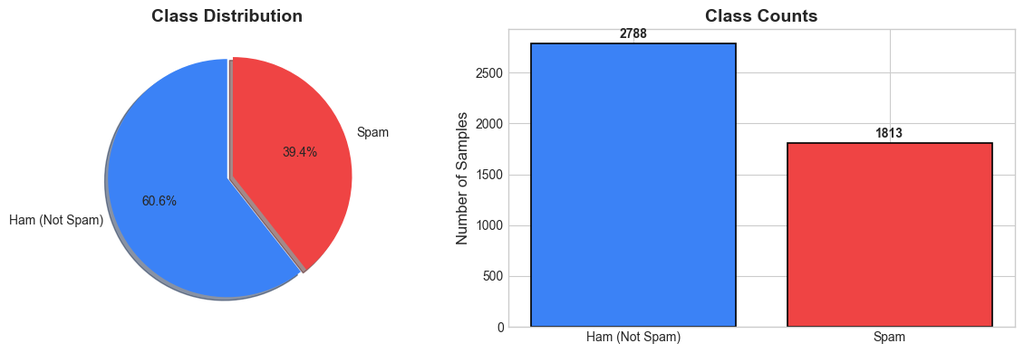

```python
# ============================================================================
# CLASS DISTRIBUTION
# ============================================================================

fig, axes = plt.subplots(1, 2, figsize=(12, 4))

# Pie chart
colors = ['#3B82F6', '#EF4444']
labels = ['Ham (Not Spam)', 'Spam']
sizes = [(y == 0).sum(), (y == 1).sum()]

axes[0].pie(sizes, labels=labels, colors=colors, autopct='%1.1f%%', startangle=90,
            explode=(0, 0.05), shadow=True)
axes[0].set_title('Class Distribution', fontsize=14, fontweight='bold')

# Bar chart
axes[1].bar(labels, sizes, color=colors, edgecolor='black', linewidth=1.2)
axes[1].set_ylabel('Number of Samples', fontsize=12)
axes[1].set_title('Class Counts', fontsize=14, fontweight='bold')
for i, v in enumerate(sizes):
    axes[1].text(i, v + 50, str(v), ha='center', fontweight='bold')

plt.tight_layout()
plt.show()
```

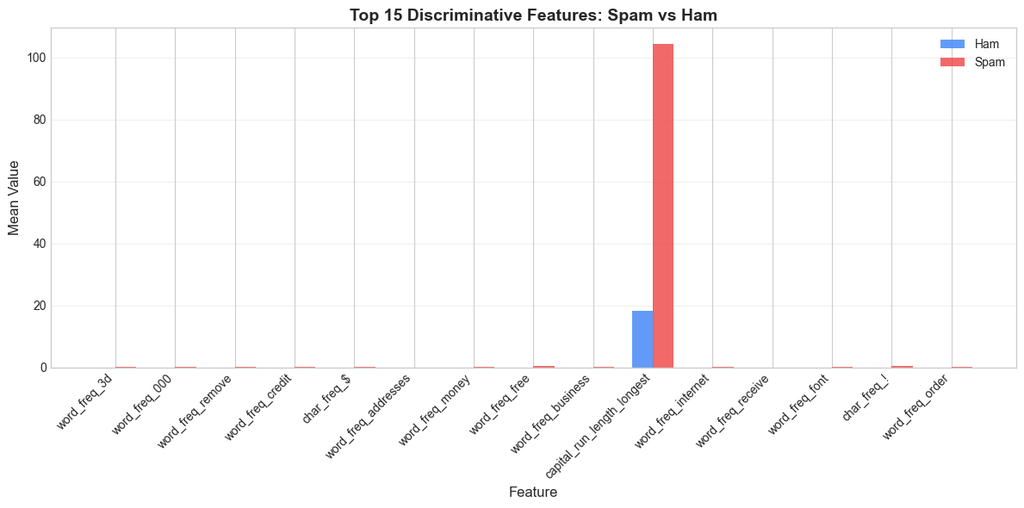

```python
# ============================================================================
# TOP DISCRIMINATIVE FEATURES (Spam vs Ham)
# ============================================================================

# Calculate mean values for spam vs ham
spam_means = df[df['spam'] == 1].drop('spam', axis=1).mean()
ham_means = df[df['spam'] == 0].drop('spam', axis=1).mean()

# Calculate difference ratio
diff_ratio = (spam_means - ham_means) / (ham_means + 0.001)
top_features = diff_ratio.abs().sort_values(ascending=False).head(15)

# Plot
fig, ax = plt.subplots(figsize=(12, 6))

x = np.arange(len(top_features))
width = 0.35

bars1 = ax.bar(x - width/2, ham_means[top_features.index], width, label='Ham', color='#3B82F6', alpha=0.8)
bars2 = ax.bar(x + width/2, spam_means[top_features.index], width, label='Spam', color='#EF4444', alpha=0.8)

ax.set_xlabel('Feature', fontsize=12)
ax.set_ylabel('Mean Value', fontsize=12)
ax.set_title('Top 15 Discriminative Features: Spam vs Ham', fontsize=14, fontweight='bold')
ax.set_xticks(x)
ax.set_xticklabels(top_features.index, rotation=45, ha='right')
ax.legend()
ax.grid(True, alpha=0.3, axis='y')

plt.tight_layout()
plt.show()
```

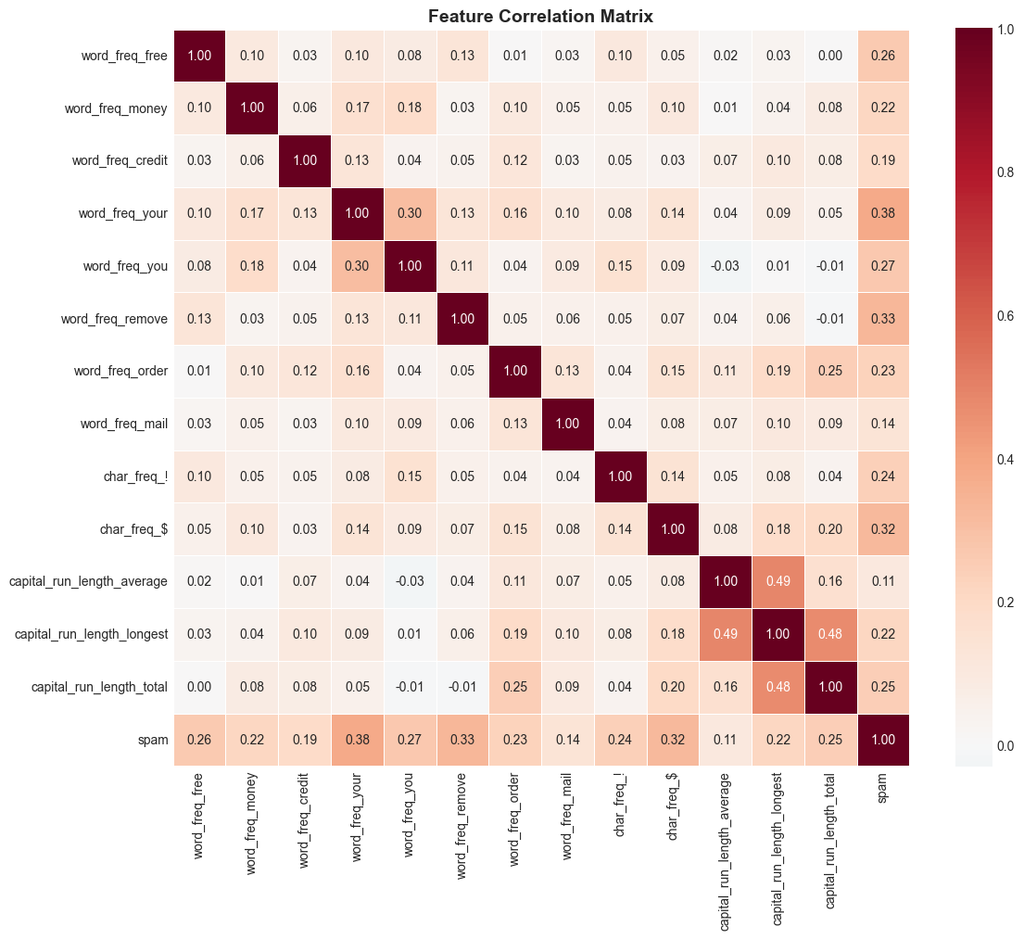

```python
# ============================================================================
# FEATURE CORRELATION HEATMAP
# ============================================================================

# Select subset of features for readability
selected_features = [
    'word_freq_free', 'word_freq_money', 'word_freq_credit', 'word_freq_your',
    'word_freq_you', 'word_freq_remove', 'word_freq_order', 'word_freq_mail',
    'char_freq_!', 'char_freq_$', 'capital_run_length_average',
    'capital_run_length_longest', 'capital_run_length_total'
]

# Check which features exist in our dataset
existing_features = [f for f in selected_features if f in df.columns]
existing_features.append('spam')

corr_matrix = df[existing_features].corr()

plt.figure(figsize=(12, 10))
sns.heatmap(corr_matrix, annot=True, cmap='RdBu_r', center=0,
            fmt='.2f', square=True, linewidths=0.5)
plt.title('Feature Correlation Matrix', fontsize=14, fontweight='bold')
plt.tight_layout()
plt.show()
```

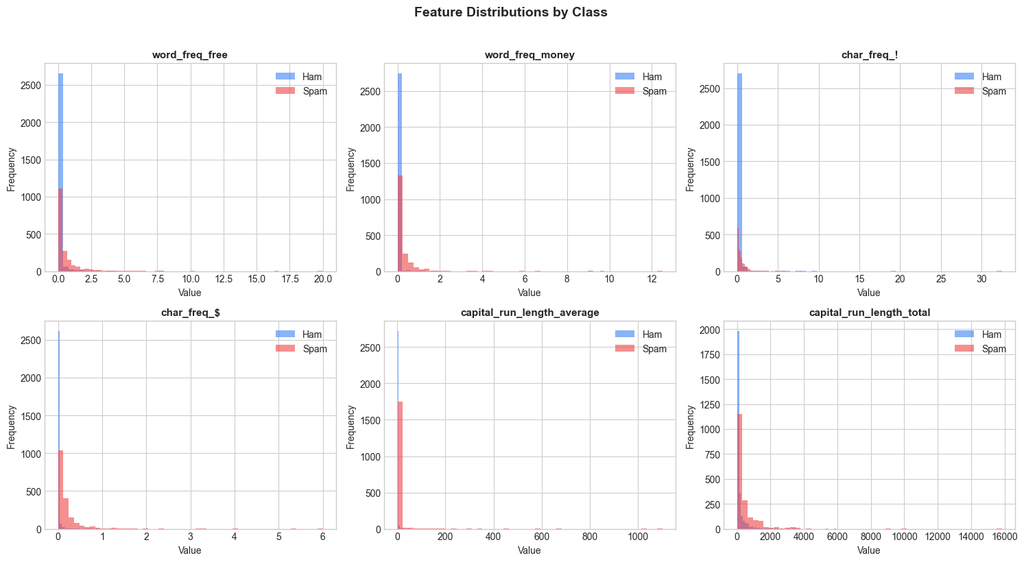

```python
# ============================================================================
# FEATURE DISTRIBUTIONS
# ============================================================================

# Select key features to visualize
key_features = ['word_freq_free', 'word_freq_money', 'char_freq_!', 'char_freq_$',
                'capital_run_length_average', 'capital_run_length_total']

# Filter to existing features
key_features = [f for f in key_features if f in df.columns][:6]

fig, axes = plt.subplots(2, 3, figsize=(15, 8))
axes = axes.flatten()

for idx, feature in enumerate(key_features):
    ax = axes[idx]

    # Plot distributions for spam and ham
    df[df['spam'] == 0][feature].hist(ax=ax, bins=50, alpha=0.6, label='Ham', color='#3B82F6')
    df[df['spam'] == 1][feature].hist(ax=ax, bins=50, alpha=0.6, label='Spam', color='#EF4444')

    ax.set_title(feature, fontsize=11, fontweight='bold')
    ax.legend()
    ax.set_xlabel('Value')
    ax.set_ylabel('Frequency')

plt.suptitle('Feature Distributions by Class', fontsize=14, fontweight='bold', y=1.02)
plt.tight_layout()
plt.show()
```

## PART 2: Data Preprocessing

### 2.1 Train-Test Split

```python
# ============================================================================
# TRAIN-TEST SPLIT
# ============================================================================

# Split data: 80% training, 20% testing
X_train, X_test, y_train, y_test = train_test_split(
    X, y, test_size=0.2, random_state=RANDOM_STATE, stratify=y
)

print("Train-Test Split:")
print(f"  Training set: {X_train.shape[0]} samples ({X_train.shape[0]/len(X)*100:.0f}%)")
print(f"  Test set:     {X_test.shape[0]} samples ({X_test.shape[0]/len(X)*100:.0f}%)")
print(f"\nClass distribution in training set:")
print(f"  Ham:  {(y_train == 0).sum()} ({(y_train == 0).mean()*100:.1f}%)")
print(f"  Spam: {(y_train == 1).sum()} ({(y_train == 1).mean()*100:.1f}%)")
```

```
Train-Test Split:
  Training set: 3680 samples (80%)
  Test set:     921 samples (20%)

Class distribution in training set:
  Ham:  2230 (60.6%)
  Spam: 1450 (39.4%)
```

### 2.2 Feature Scaling

Some algorithms (like k-NN) are sensitive to feature scales. We'll use StandardScaler to normalize the features.

```python
# ============================================================================
# FEATURE SCALING
# ============================================================================

# StandardScaler for algorithms sensitive to scale (k-NN, Oblique Tree)
scaler = StandardScaler()

# Fit on training data, transform both
X_train_scaled = scaler.fit_transform(X_train)
X_test_scaled = scaler.transform(X_test)

# Convert back to DataFrame for convenience
X_train_scaled = pd.DataFrame(X_train_scaled, columns=feature_names)
X_test_scaled = pd.DataFrame(X_test_scaled, columns=feature_names)

print("Feature scaling applied (StandardScaler)")
print(f"\nScaled training data - Mean: {X_train_scaled.mean().mean():.6f}, Std: {X_train_scaled.std().mean():.6f}")
```

```
Feature scaling applied (StandardScaler)

Scaled training data - Mean: 0.000000, Std: 1.000136
```

## PART 3: Model Implementation & Training

### 3.1 Oblique Decision Tree Implementation

Custom implementation using ISTA (Iterative Shrinkage-Thresholding Algorithm) for sparse linear splits.

```python
# ============================================================================
# OBLIQUE DECISION TREE - HELPER FUNCTIONS
# ============================================================================

def sigmoid(z):
    """Numerically stable sigmoid function."""
    z = np.clip(z, -20, 20)
    return 1.0 / (1.0 + np.exp(-z))

def soft_threshold(x, lambda_):
    """Proximal operator for L1 norm (soft thresholding)."""
    return np.sign(x) * np.maximum(np.abs(x) - lambda_, 0.0)

def compute_loss_and_gradients(X, y, weights, bias):
    """Compute logistic loss and gradients."""
    n_samples = X.shape[0]
    linear_scores = X @ weights + bias
    probs = sigmoid(linear_scores)

    epsilon = 1e-12
    probs_clipped = np.clip(probs, epsilon, 1 - epsilon)
    loss = -np.sum(y * np.log(probs_clipped) + (1 - y) * np.log(1 - probs_clipped)) / n_samples

    error = (probs - y) / n_samples
    grad_weights = X.T @ error
    grad_bias = np.sum(error)

    return loss, grad_weights, grad_bias

def train_logistic_ista(X, y, l1_lambda=0.01, max_iter=100, lr=0.1, tol=1e-5):
    """Train logistic regression with L1 penalty using ISTA."""
    n_samples, n_features = X.shape
    weights = np.zeros(n_features)
    bias = 0.0

    for _ in range(max_iter):
        _, grad_w, grad_b = compute_loss_and_gradients(X, y, weights, bias)

        # Gradient step
        weights_temp = weights - lr * grad_w
        bias_new = bias - lr * grad_b

        # Proximal step (soft thresholding for L1)
        weights_new = soft_threshold(weights_temp, lr * l1_lambda) if l1_lambda > 0 else weights_temp

        # Check convergence
        if np.linalg.norm(weights_new - weights) < tol and abs(bias_new - bias) < tol:
            break

        weights, bias = weights_new, bias_new

    return weights, bias

print("✓ Oblique Tree helper functions defined")
```

```
✓ Oblique Tree helper functions defined
```

```python
# ============================================================================
# OBLIQUE DECISION TREE - NODE CLASS
# ============================================================================

class ObliqueNode:
    """Node for Oblique Decision Tree."""
    def __init__(self):
        self.is_leaf = True
        self.weights = None
        self.bias = None
        self.left_child = None
        self.right_child = None
        self.class_probs = None
        self.predicted_class = None
        self.n_samples = 0

print("✓ ObliqueNode class defined")
```

```
✓ ObliqueNode class defined
```

```python
# ============================================================================
# OBLIQUE DECISION TREE - MAIN CLASS
# ============================================================================

class ObliqueDecisionTree(BaseEstimator, ClassifierMixin):
    """
    Oblique Decision Tree with linear (non-axis-aligned) splits.
    Uses L1 regularization for sparse, interpretable splits.
    """

    def __init__(self, max_depth=5, min_samples_split=10, min_samples_leaf=5,
                 l1_regularization=0.01, random_state=None):
        self.max_depth = max_depth
        self.min_samples_split = min_samples_split
        self.min_samples_leaf = min_samples_leaf
        self.l1_regularization = l1_regularization
        self.random_state = random_state
        self.root = None
        self.n_classes_ = None
        self.classes_ = None
        self.n_features_ = None

    def _gini_impurity(self, y):
        """Calculate Gini impurity."""
        if len(y) == 0:
            return 0.0
        probs = np.bincount(y, minlength=self.n_classes_) / len(y)
        return 1.0 - np.sum(probs ** 2)

    def _find_best_split(self, X, y):
        """Find best oblique split using logistic regression."""
        n_samples = X.shape[0]

        if n_samples < self.min_samples_split:
            return None, None

        # Use fast logistic regression for initial split direction
        try:
            lr = LogisticRegression(
                penalty='l1', solver='liblinear', C=1.0/(self.l1_regularization + 1e-6),
                random_state=self.random_state, max_iter=100
            )
            lr.fit(X, y)
            weights = lr.coef_.ravel()
            bias = lr.intercept_[0]
        except:
            return None, None

        # Refine with ISTA for sparsity
        weights, bias = train_logistic_ista(X, y, l1_lambda=self.l1_regularization)

        # Check if split is valid
        scores = X @ weights + bias
        left_mask = scores < 0
        right_mask = ~left_mask

        if left_mask.sum() < self.min_samples_leaf or right_mask.sum() < self.min_samples_leaf:
            return None, None

        return weights, bias

    def _build_tree(self, X, y, depth=0):
        """Recursively build the tree."""
        node = ObliqueNode()
        node.n_samples = len(y)

        # Calculate class probabilities
        class_counts = np.bincount(y, minlength=self.n_classes_)
        node.class_probs = class_counts / len(y)
        node.predicted_class = np.argmax(class_counts)

        # Check stopping conditions
        if (depth >= self.max_depth or
            len(y) < self.min_samples_split or
            len(np.unique(y)) == 1):
            return node

        # Find best split
        weights, bias = self._find_best_split(X, y)

        if weights is None:
            return node

        # Create split
        node.is_leaf = False
        node.weights = weights
        node.bias = bias

        scores = X @ weights + bias
        left_mask = scores < 0
        right_mask = ~left_mask

        # Recursively build children
        node.left_child = self._build_tree(X[left_mask], y[left_mask], depth + 1)
        node.right_child = self._build_tree(X[right_mask], y[right_mask], depth + 1)

        return node

    def fit(self, X, y):
        """Fit the oblique decision tree."""
        X = np.asarray(X)
        y = np.asarray(y)

        self.classes_ = np.unique(y)
        self.n_classes_ = len(self.classes_)
        self.n_features_ = X.shape[1]

        if self.random_state is not None:
            np.random.seed(self.random_state)

        self.root = self._build_tree(X, y)
        return self

    def _predict_single(self, x, node):
        """Predict class for a single sample."""
        if node.is_leaf:
            return node.class_probs

        score = np.dot(x, node.weights) + node.bias
        if score < 0:
            return self._predict_single(x, node.left_child)
        else:
            return self._predict_single(x, node.right_child)

    def predict_proba(self, X):
        """Predict class probabilities."""
        X = np.asarray(X)
        return np.array([self._predict_single(x, self.root) for x in X])

    def predict(self, X):
        """Predict class labels."""
        proba = self.predict_proba(X)
        return self.classes_[np.argmax(proba, axis=1)]

print("✓ ObliqueDecisionTree class defined")
```

```
✓ ObliqueDecisionTree class defined
```

### 3.2 Define All Models

```python
# ============================================================================
# MODEL DEFINITIONS
# ============================================================================

models = {
    'CART': {
        'model': DecisionTreeClassifier(
            criterion='gini',
            max_depth=10,
            min_samples_split=10,
            min_samples_leaf=5,
            random_state=RANDOM_STATE
        ),
        'use_scaled': False,  # CART doesn't need scaling
        'color': '#3B82F6'
    },
    'k-NN': {
        'model': KNeighborsClassifier(
            n_neighbors=5,
            weights='distance',
            metric='minkowski',
            p=2
        ),
        'use_scaled': True,  # k-NN needs scaling
        'color': '#10B981'
    },
    'Random Forest': {
        'model': RandomForestClassifier(
            n_estimators=100,
            criterion='gini',
            max_depth=15,
            min_samples_split=5,
            min_samples_leaf=2,
            random_state=RANDOM_STATE,
            n_jobs=-1
        ),
        'use_scaled': False,  # Random Forest doesn't need scaling
        'color': '#F59E0B'
    },
    'Oblique Tree': {
        'model': ObliqueDecisionTree(
            max_depth=6,
            min_samples_split=20,
            min_samples_leaf=10,
            l1_regularization=0.05,
            random_state=RANDOM_STATE
        ),
        'use_scaled': True,  # Oblique Tree benefits from scaling
        'color': '#EF4444'
    }
}

print("Models defined:")
for name in models:
    print(f"  ✓ {name}")
```

```
Models defined:
  ✓ CART
  ✓ k-NN
  ✓ Random Forest
  ✓ Oblique Tree
```

### 3.3 Train Models

```python
# ============================================================================
# TRAIN ALL MODELS
# ============================================================================

results = {}

print("Training models...\n")
print("=" * 60)

for name, config in models.items():
    print(f"\nTraining {name}...")

    # Select appropriate data (scaled or not)
    if config['use_scaled']:
        X_tr, X_te = X_train_scaled.values, X_test_scaled.values
    else:
        X_tr, X_te = X_train.values, X_test.values

    # Train model and measure time
    start_time = time.time()
    model = config['model']
    model.fit(X_tr, y_train)
    train_time = time.time() - start_time

    # Predict and measure time
    start_time = time.time()
    y_pred = model.predict(X_te)
    y_proba = model.predict_proba(X_te)[:, 1] if hasattr(model, 'predict_proba') else None
    test_time = time.time() - start_time

    # Calculate metrics
    results[name] = {
        'model': model,
        'y_pred': y_pred,
        'y_proba': y_proba,
        'accuracy': accuracy_score(y_test, y_pred),
        'precision': precision_score(y_test, y_pred),
        'recall': recall_score(y_test, y_pred),
        'f1': f1_score(y_test, y_pred),
        'roc_auc': roc_auc_score(y_test, y_proba) if y_proba is not None else None,
        'train_time': train_time,
        'test_time': test_time,
        'color': config['color']
    }

    print(f"  ✓ Accuracy: {results[name]['accuracy']:.4f}")
    print(f"  ✓ Training time: {train_time:.4f}s")

print("\n" + "=" * 60)
print("All models trained successfully!")
```

```
Training models...

============================================================

Training CART...
  ✓ Accuracy: 0.9088
  ✓ Training time: 0.0397s

Training k-NN...
  ✓ Accuracy: 0.9110
  ✓ Training time: 0.0025s

Training Random Forest...
  ✓ Accuracy: 0.9359
  ✓ Training time: 0.2981s

Training Oblique Tree...
  ✓ Accuracy: 0.8328
  ✓ Training time: 1.9161s

============================================================
All models trained successfully!
```

## PART 4: Evaluation & Comparison

### 4.1 Metrics Summary Table

```python
# ============================================================================
# RESULTS TABLE
# ============================================================================

metrics_df = pd.DataFrame({
    'Model': list(results.keys()),
    'Accuracy': [results[m]['accuracy'] for m in results],
    'Precision': [results[m]['precision'] for m in results],
    'Recall': [results[m]['recall'] for m in results],
    'F1-Score': [results[m]['f1'] for m in results],
    'ROC-AUC': [results[m]['roc_auc'] for m in results],
    'Train Time (s)': [results[m]['train_time'] for m in results],
    'Test Time (s)': [results[m]['test_time'] for m in results]
})

# Sort by F1-Score
metrics_df = metrics_df.sort_values('F1-Score', ascending=False).reset_index(drop=True)

print("\n" + "=" * 80)
print("MODEL COMPARISON - PERFORMANCE METRICS")
print("=" * 80)
print(metrics_df.to_string(index=False))
print("=" * 80)
```

```
================================================================================
MODEL COMPARISON - PERFORMANCE METRICS
================================================================================
        Model  Accuracy  Precision   Recall  F1-Score  ROC-AUC  Train Time (s)  Test Time (s)
Random Forest  0.935939   0.947059 0.887052  0.916074 0.983432        0.298082       0.073398
         k-NN  0.910966   0.889197 0.884298  0.886740 0.954600        0.002516       2.885004
         CART  0.908795   0.899713 0.865014  0.882022 0.937246        0.039656       0.000000
 Oblique Tree  0.832790   0.906615 0.641873  0.751613 0.799431        1.916083       0.003178
================================================================================
```

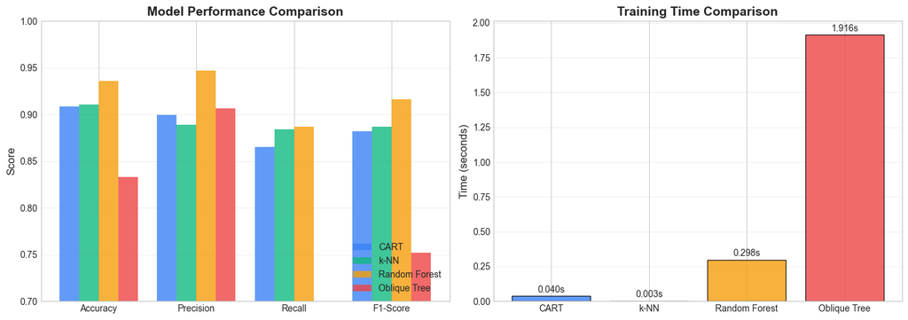

```python
# ============================================================================
# METRICS BAR CHART
# ============================================================================

fig, axes = plt.subplots(1, 2, figsize=(14, 5))

# Performance metrics
metrics = ['Accuracy', 'Precision', 'Recall', 'F1-Score']
x = np.arange(len(metrics))
width = 0.2

ax = axes[0]
for i, (name, res) in enumerate(results.items()):
    values = [res['accuracy'], res['precision'], res['recall'], res['f1']]
    ax.bar(x + i * width, values, width, label=name, color=res['color'], alpha=0.8)

ax.set_ylabel('Score', fontsize=12)
ax.set_title('Model Performance Comparison', fontsize=14, fontweight='bold')
ax.set_xticks(x + width * 1.5)
ax.set_xticklabels(metrics)
ax.legend(loc='lower right')
ax.set_ylim(0.7, 1.0)
ax.grid(True, alpha=0.3, axis='y')

# Training time comparison
ax = axes[1]
names = list(results.keys())
colors = [results[n]['color'] for n in names]
train_times = [results[n]['train_time'] for n in names]

bars = ax.bar(names, train_times, color=colors, alpha=0.8, edgecolor='black')
ax.set_ylabel('Time (seconds)', fontsize=12)
ax.set_title('Training Time Comparison', fontsize=14, fontweight='bold')
ax.grid(True, alpha=0.3, axis='y')

# Add value labels
for bar, time_val in zip(bars, train_times):
    ax.text(bar.get_x() + bar.get_width()/2, bar.get_height() + 0.01,
            f'{time_val:.3f}s', ha='center', va='bottom', fontsize=10)

plt.tight_layout()
plt.show()
```

### 4.2 Confusion Matrices

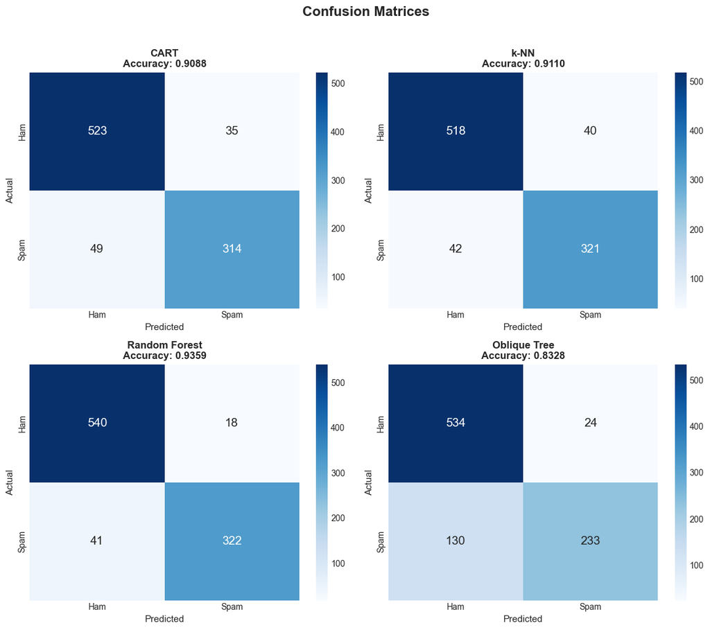

```python
# ============================================================================
# CONFUSION MATRICES
# ============================================================================

fig, axes = plt.subplots(2, 2, figsize=(12, 10))
axes = axes.flatten()

for idx, (name, res) in enumerate(results.items()):
    ax = axes[idx]
    cm = confusion_matrix(y_test, res['y_pred'])

    sns.heatmap(cm, annot=True, fmt='d', cmap='Blues', ax=ax,
                xticklabels=['Ham', 'Spam'], yticklabels=['Ham', 'Spam'],
                annot_kws={'size': 14})

    ax.set_title(f'{name}\nAccuracy: {res["accuracy"]:.4f}', fontsize=12, fontweight='bold')
    ax.set_xlabel('Predicted', fontsize=11)
    ax.set_ylabel('Actual', fontsize=11)

plt.suptitle('Confusion Matrices', fontsize=16, fontweight='bold', y=1.02)
plt.tight_layout()
plt.show()
```

### 4.3 ROC Curves

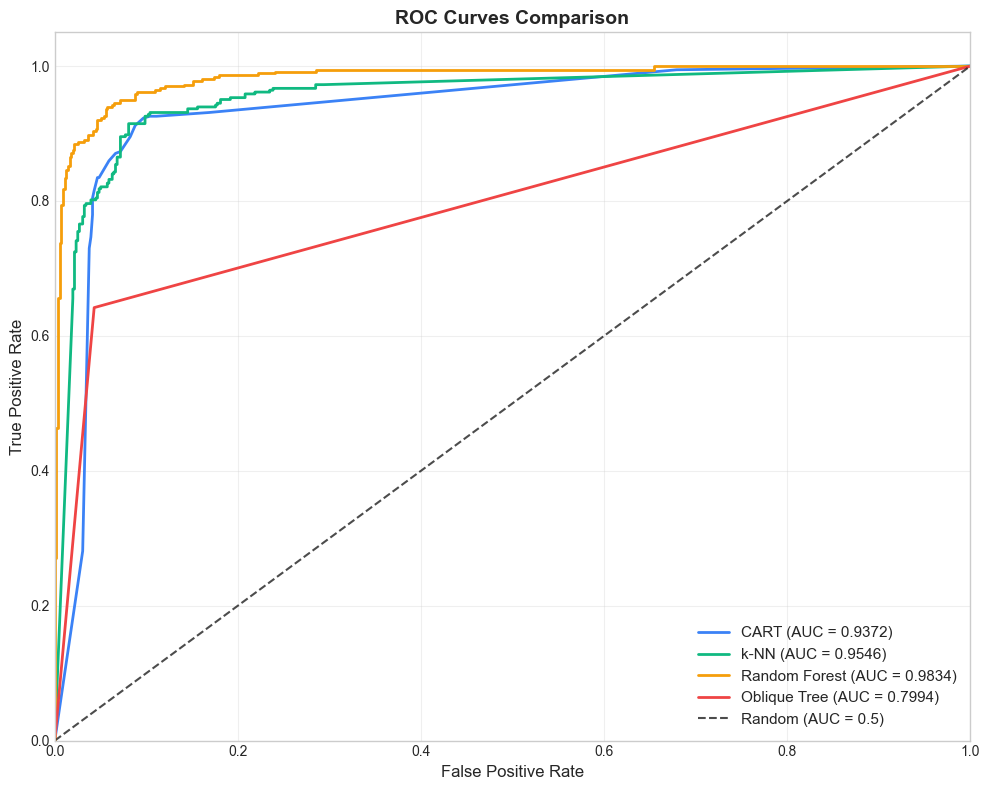

```python
# ============================================================================
# ROC CURVES
# ============================================================================

plt.figure(figsize=(10, 8))

for name, res in results.items():
    if res['y_proba'] is not None:
        fpr, tpr, _ = roc_curve(y_test, res['y_proba'])
        roc_auc = auc(fpr, tpr)
        plt.plot(fpr, tpr, color=res['color'], lw=2,
                 label=f'{name} (AUC = {roc_auc:.4f})')

# Diagonal line (random classifier)
plt.plot([0, 1], [0, 1], 'k--', lw=1.5, alpha=0.7, label='Random (AUC = 0.5)')

plt.xlim([0.0, 1.0])
plt.ylim([0.0, 1.05])
plt.xlabel('False Positive Rate', fontsize=12)
plt.ylabel('True Positive Rate', fontsize=12)
plt.title('ROC Curves Comparison', fontsize=14, fontweight='bold')
plt.legend(loc='lower right', fontsize=11)
plt.grid(True, alpha=0.3)
plt.tight_layout()
plt.show()
```

### 4.4 Classification Reports

```python
# ============================================================================
# DETAILED CLASSIFICATION REPORTS
# ============================================================================

for name, res in results.items():
    print("\n" + "=" * 60)
    print(f"CLASSIFICATION REPORT: {name}")
    print("=" * 60)
    print(classification_report(y_test, res['y_pred'], target_names=['Ham', 'Spam']))
```

```
============================================================
CLASSIFICATION REPORT: CART
============================================================
              precision    recall  f1-score   support

         Ham       0.91      0.94      0.93       558
        Spam       0.90      0.87      0.88       363

    accuracy                           0.91       921
   macro avg       0.91      0.90      0.90       921
weighted avg       0.91      0.91      0.91       921


============================================================
CLASSIFICATION REPORT: k-NN
============================================================
              precision    recall  f1-score   support

         Ham       0.93      0.93      0.93       558
        Spam       0.89      0.88      0.89       363

    accuracy                           0.91       921
   macro avg       0.91      0.91      0.91       921
weighted avg       0.91      0.91      0.91       921


============================================================
CLASSIFICATION REPORT: Random Forest
============================================================
              precision    recall  f1-score   support

         Ham       0.93      0.97      0.95       558
        Spam       0.95      0.89      0.92       363

    accuracy                           0.94       921
   macro avg       0.94      0.93      0.93       921
weighted avg       0.94      0.94      0.94       921


============================================================
CLASSIFICATION REPORT: Oblique Tree
============================================================
              precision    recall  f1-score   support

         Ham       0.80      0.96      0.87       558
        Spam       0.91      0.64      0.75       363

    accuracy                           0.83       921
   macro avg       0.86      0.80      0.81       921
weighted avg       0.84      0.83      0.83       921
```

## PART 5: Advanced Analysis

### 5.1 Learning Curves

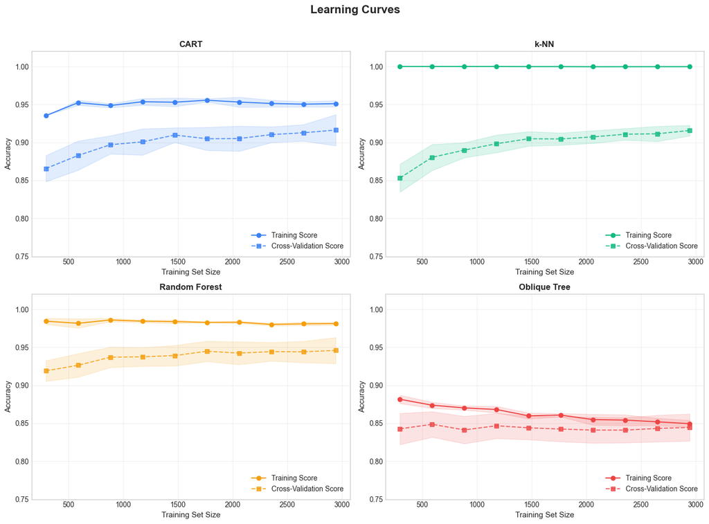

```python
# ============================================================================
# LEARNING CURVES
# ============================================================================

fig, axes = plt.subplots(2, 2, figsize=(14, 10))
axes = axes.flatten()

train_sizes = np.linspace(0.1, 1.0, 10)

for idx, (name, config) in enumerate(models.items()):
    ax = axes[idx]

    # Get appropriate data
    if config['use_scaled']:
        X_data, y_data = X_train_scaled.values, y_train
    else:
        X_data, y_data = X_train.values, y_train

    # Calculate learning curve
    train_sizes_abs, train_scores, val_scores = learning_curve(
        config['model'], X_data, y_data,
        train_sizes=train_sizes, cv=5, scoring='accuracy',
        n_jobs=-1, random_state=RANDOM_STATE
    )

    # Calculate mean and std
    train_mean = np.mean(train_scores, axis=1)
    train_std = np.std(train_scores, axis=1)
    val_mean = np.mean(val_scores, axis=1)
    val_std = np.std(val_scores, axis=1)

    # Plot
    ax.plot(train_sizes_abs, train_mean, 'o-', color=results[name]['color'],
            label='Training Score')
    ax.fill_between(train_sizes_abs, train_mean - train_std, train_mean + train_std,
                    alpha=0.15, color=results[name]['color'])

    ax.plot(train_sizes_abs, val_mean, 's--', color=results[name]['color'],
            label='Cross-Validation Score', alpha=0.8)
    ax.fill_between(train_sizes_abs, val_mean - val_std, val_mean + val_std,
                    alpha=0.15, color=results[name]['color'])

    ax.set_xlabel('Training Set Size', fontsize=11)
    ax.set_ylabel('Accuracy', fontsize=11)
    ax.set_title(f'{name}', fontsize=12, fontweight='bold')
    ax.legend(loc='lower right')
    ax.grid(True, alpha=0.3)
    ax.set_ylim(0.75, 1.02)

plt.suptitle('Learning Curves', fontsize=16, fontweight='bold', y=1.02)
plt.tight_layout()
plt.show()
```

### 5.2 Feature Importance (for Tree-based Models)

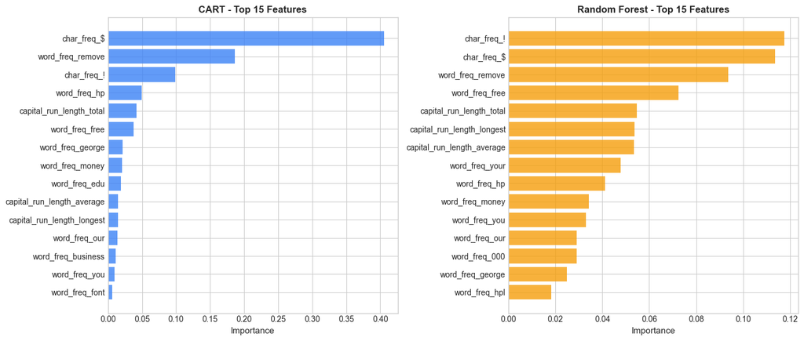

```python
# ============================================================================
# FEATURE IMPORTANCE - CART & RANDOM FOREST
# ============================================================================

fig, axes = plt.subplots(1, 2, figsize=(14, 6))

# CART Feature Importance
cart_model = results['CART']['model']
cart_importance = pd.DataFrame({
    'feature': feature_names,
    'importance': cart_model.feature_importances_
}).sort_values('importance', ascending=False).head(15)

axes[0].barh(cart_importance['feature'], cart_importance['importance'],
             color=results['CART']['color'], alpha=0.8)
axes[0].set_xlabel('Importance', fontsize=11)
axes[0].set_title('CART - Top 15 Features', fontsize=12, fontweight='bold')
axes[0].invert_yaxis()

# Random Forest Feature Importance
rf_model = results['Random Forest']['model']
rf_importance = pd.DataFrame({
    'feature': feature_names,
    'importance': rf_model.feature_importances_
}).sort_values('importance', ascending=False).head(15)

axes[1].barh(rf_importance['feature'], rf_importance['importance'],
             color=results['Random Forest']['color'], alpha=0.8)
axes[1].set_xlabel('Importance', fontsize=11)
axes[1].set_title('Random Forest - Top 15 Features', fontsize=12, fontweight='bold')
axes[1].invert_yaxis()

plt.tight_layout()
plt.show()
```

### 5.3 Cross-Validation Scores

```python
# ============================================================================
# CROSS-VALIDATION SCORES (5-Fold)
# ============================================================================

cv = StratifiedKFold(n_splits=5, shuffle=True, random_state=RANDOM_STATE)
cv_results = {}

print("5-Fold Cross-Validation Results:")
print("=" * 60)

for name, config in models.items():
    # Get appropriate data
    if config['use_scaled']:
        X_data = X_train_scaled.values
    else:
        X_data = X_train.values

    # Perform cross-validation
    scores = cross_val_score(config['model'], X_data, y_train, cv=cv, scoring='accuracy')
    cv_results[name] = scores

    print(f"\n{name}:")
    print(f"  Fold scores: {scores.round(4)}")
    print(f"  Mean: {scores.mean():.4f} (+/- {scores.std() * 2:.4f})")
```

```
5-Fold Cross-Validation Results:
============================================================

CART:
  Fold scores: [0.9266 0.9375 0.9239 0.913  0.9103]
  Mean: 0.9223 (+/- 0.0196)

k-NN:
  Fold scores: [0.928  0.9171 0.9198 0.9198 0.9008]
  Mean: 0.9171 (+/- 0.0179)

Random Forest:
  Fold scores: [0.9511 0.947  0.9443 0.9416 0.9443]
  Mean: 0.9457 (+/- 0.0064)

Oblique Tree:
  Fold scores: [0.8478 0.8573 0.8546 0.8383 0.837 ]
  Mean: 0.8470 (+/- 0.0165)
```

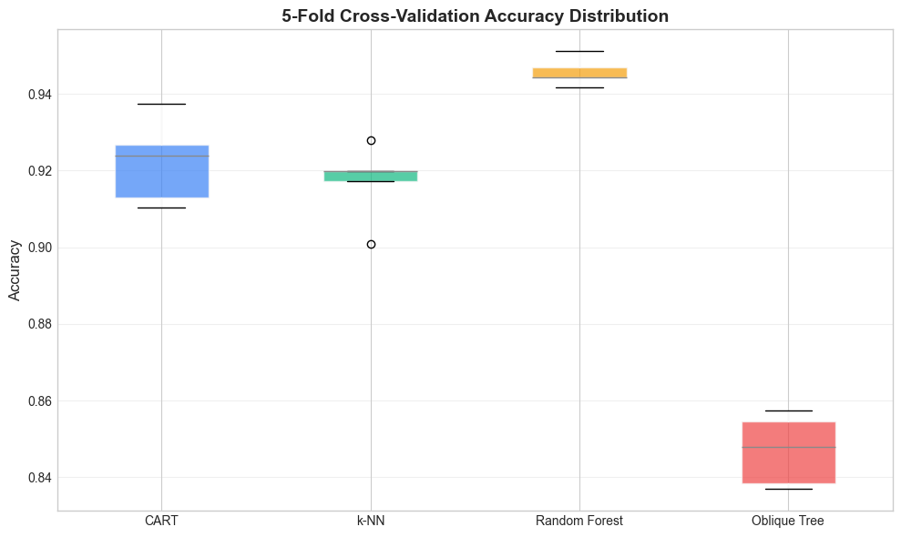

```python
# ============================================================================
# CROSS-VALIDATION BOX PLOT
# ============================================================================

plt.figure(figsize=(10, 6))

cv_df = pd.DataFrame(cv_results)
colors = [results[name]['color'] for name in cv_df.columns]

bp = cv_df.boxplot(patch_artist=True, return_type='dict')

# Color the boxes
for patch, color in zip(bp['boxes'], colors):
    patch.set_facecolor(color)
    patch.set_alpha(0.7)

plt.ylabel('Accuracy', fontsize=12)
plt.title('5-Fold Cross-Validation Accuracy Distribution', fontsize=14, fontweight='bold')
plt.grid(True, alpha=0.3, axis='y')
plt.tight_layout()
plt.show()
```